# Week 1: Introduction to Machine Learning for Marketing

# 6 Putting It Together — A First End-to-End Example

Now let’s combine everything from Chapters 1, 3, and 5 into a simple but complete modeling workflow. We will use the training data only for fitting and save the test set for the end.

## 6.1 Step 1 — Split the data

```r
set.seed(123)

final_split <- initial_split(customer_data, prop = 0.80, strata = churn)
final_train <- training(final_split)
final_test <- testing(final_split)

cat("Training:", nrow(final_train), "rows\n")
```

```
Training: 799 rows
```

```r
cat("Testing: ", nrow(final_test), "rows\n")
```

```
Testing:  201 rows
```

## 6.2 Step 2 — Explore the training data only

**Warning**

All exploratory analysis should use **training data only**. If you explore the test set and let that influence your modeling decisions, you are leaking information and your final performance estimate will be optimistic.

```r
# Churn rate by number of complaints
final_train |>
  group_by(num_complaints) |>
  summarise(
    n = n(),
    churn_rate = mean(churn == "yes") * 100
  ) |>
  filter(n >= 10)
```

| num_complaints | n | churn_rate |
| --- | --- | --- |
| 0 | 469 | 35.60768 |
| 1 | 254 | 38.58268 |
| 2 | 57 | 35.08772 |
| 3 | 17 | 58.82353 |

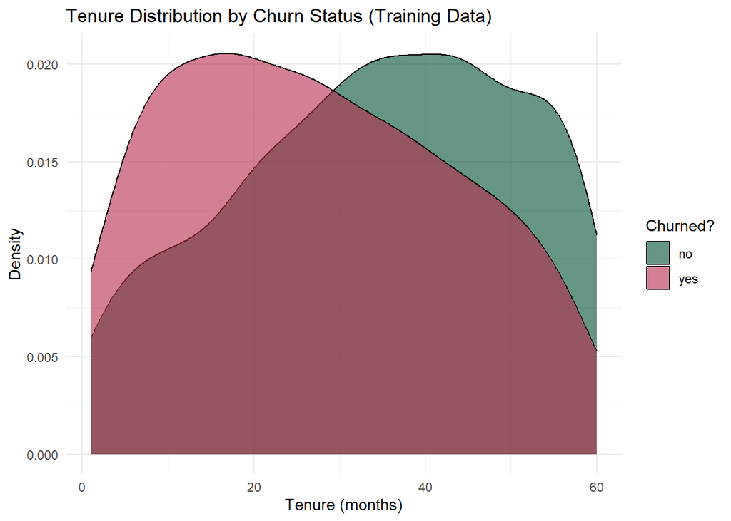

```r
# Distribution of tenure by churn status
final_train |>
  ggplot(aes(x = tenure, fill = churn)) +
  geom_density(alpha = 0.6) +
  scale_fill_manual(values = c("no" = "#005030", "yes" = "#B52B4C")) +
  labs(
    title = "Tenure Distribution by Churn Status (Training Data)",
    x = "Tenure (months)",
    y = "Density",
    fill = "Churned?"
  ) +
  theme_minimal()
```

## 6.3 Step 3 — Fit a model on training data

```r
# Logistic regression using base R (we will use parsnip next week)
churn_fit <- glm(
  churn ~ tenure +
    monthly_spend +
    num_products +
    num_complaints +
    last_login_days,
  data = final_train,
  family = binomial
)

tidy(churn_fit)
```

| term | estimate | std.error | statistic | p.value |
| --- | --- | --- | --- | --- |
| (Intercept) | -1.75969599 | 0.466058472 | -3.775698 | 1.595603e-04 |
| tenure | -0.05105458 | 0.006685860 | -7.636203 | 2.237223e-14 |
| monthly_spend | -0.01493599 | 0.003848837 | -3.880649 | 1.041780e-04 |
| num_products | 0.12366123 | 0.076792048 | 1.610339 | 1.073239e-01 |
| num_complaints | 0.17241238 | 0.133809071 | 1.288495 | 1.975736e-01 |
| last_login_days | 0.07179928 | 0.005074585 | 14.148799 | 1.899740e-45 |

```r
glance(churn_fit)
```

| null.deviance | df.null | logLik | AIC | BIC | deviance | df.residual | nobs |
| --- | --- | --- | --- | --- | --- | --- | --- |
| 1052.338 | 798 | -324.0256 | 660.0513 | 688.1515 | 648.0513 | 793 | 799 |

## 6.4 Step 4 — Evaluate on the test set (once!)

```r
# Generate predictions on the test set
test_predictions <- augment(
  churn_fit,
  newdata = final_test,
  type.predict = "response"
) |>
  mutate(
    .pred_class = factor(ifelse(.fitted > 0.5, "yes", "no"))
  )

# Confusion matrix
conf_mat_result <- conf_mat(
  test_predictions,
  truth = churn,
  estimate = .pred_class
)

conf_mat_result
```

```
          Truth
Prediction  no yes
       no  108  20
       yes  19  54
```

```r
# Accuracy
accuracy(test_predictions, truth = churn, estimate = .pred_class)
```

| .metric | .estimator | .estimate |
| --- | --- | --- |
| accuracy | binary | 0.8059701 |

**Note**

We are using this simple threshold (0.5) for illustration. In later weeks we will learn how to choose thresholds based on marketing decision context and how to evaluate models more rigorously using resampling.

# 7 Chapter Summaries

## 7.1 Chapter 1 takeaways

- Models can be **descriptive**, **inferential**, or **predictive** — know which type you need before you start
- Good modeling software should be **consistent**, **safe**, and **expressive** — tidymodels is designed with these principles
- Modeling is an **iterative process**, not a linear one

## 7.2 Chapter 3 takeaways

- The R formula interface (`~`) is powerful and expressive
- Base R model output is hard to work with — `broom` functions (`tidy()`, `glance()`, `augment()`) solve this
- tidymodels provides a **unified interface** across model types so you do not need to learn different syntax for every algorithm

## 7.3 Chapter 5 takeaways

- The **data budget**: every use of data for a decision “spends” some of its ability to give unbiased estimates
- Always split into **training** and **testing** before any modeling
- Use **stratified splits** when outcome classes are imbalanced
- Never use the test set more than once — doing so leads to overfitting to the test data

# 8 Exercises

Complete these before the next class.

## 8.1 Exercise 1 — Broom practice

Using the `customer_data` dataset (before splitting):

1. Fit a linear regression predicting `monthly_spend` from `tenure`, `num_products`, and `region`
2. Use `tidy()` to extract coefficients. Which predictors are significant at the 0.05 level?
3. Use `glance()` to check R². Is the model a good fit?
4. Use `augment()` and ggplot2 to create a residual plot. Do you see any patterns?

```r
# YOUR CODE HERE
spend_model <- lm(___ ~ ___ + ___ + ___, data = customer_data)
tidy(___)
glance(___)
augment(___) |>
  ggplot(aes(x = ___, y = ___)) +
  geom_point()
```

## 8.2 Exercise 2 — Data splitting

Using the `customer_data` dataset:

1. Create a **70/30** stratified split on `churn`
2. Verify that the churn rate is similar in both sets
3. Check whether the distribution of `last_login_days` looks similar in training and testing

```r
set.seed(456)

# YOUR CODE HERE
ex2_split <- initial_split(customer_data, prop = ___, strata = ___)
ex2_train <- training(___)
ex2_test <- testing(___)

# Verify churn rate
ex2_train |> count(___) |> mutate(pct = n / sum(n))
ex2_test |> count(___) |> mutate(pct = n / sum(n))
```

## 8.3 Exercise 3 — Critical thinking

Answer the following in 2–3 sentences each:

1. A colleague says: “I looked at the test set to understand the data better before modeling. I did not fit any models on it.” Is this a problem? Why or why not?
2. You are building a fraud detection model. Only 0.1% of transactions are fraudulent. Why is stratified splitting especially important here?
3. A model achieves 92% accuracy on the training set and 61% accuracy on the test set. What does this tell you? What would you do next?

# 9 Resources

| Resource | Link |
| --- | --- |
| Tidy Modeling with R (free) | tmwr.org |
| tidymodels documentation | tidymodels.org |
| rsample reference | rsample.tidymodels.org |
| broom reference | broom.tidymodels.org |
| R for Data Science | r4ds.hadley.nz |

*IBM 6540 • Applied Machine Learning with tidymodels • Cal Poly Pomona*